# Admissions Analysis - Good Luck!

2025-04-17

### I will be analyzing the dataset gradschool admissions for Assignment 9.

Loading the needed packages:

```r
library(gapminder)
library(tidyverse)
library(patchwork)
library(GGally)
library(ggplot2)
library(dplyr)
library(grid)
library(easystats)
library(janitor)
library(skimr)
library(MASS)
library(caret)
library(ggpubr)
```

Next, we’ll want to look at the dataset

```r
glimpse(admits)
```

```
## Rows: 400
## Columns: 4
## $ admit <int> 0, 1, 1, 1, 0, 1, 1, 0, 1, 0, 0, 0, 1, 0, 1, 0, 0, 0, 0, 1, 0, 1…
## $ gre   <int> 380, 660, 800, 640, 520, 760, 560, 400, 540, 700, 800, 440, 760,…
## $ gpa   <dbl> 3.61, 3.67, 4.00, 3.19, 2.93, 3.00, 2.98, 3.08, 3.39, 3.92, 4.00…
## $ rank  <int> 3, 3, 1, 4, 4, 2, 1, 2, 3, 2, 4, 1, 1, 2, 1, 3, 4, 3, 2, 1, 3, 2…
```

The column admit is classified as number, as will be seen, this will need to be classified as logical for later analysis.

The goal of this assignment is to analyze the variable and create a good model to predict the probability of being accepted to graduate school.

## Previewing the data with plots

The data is first plotted to look for any obvious correlations between a single variable and admit.

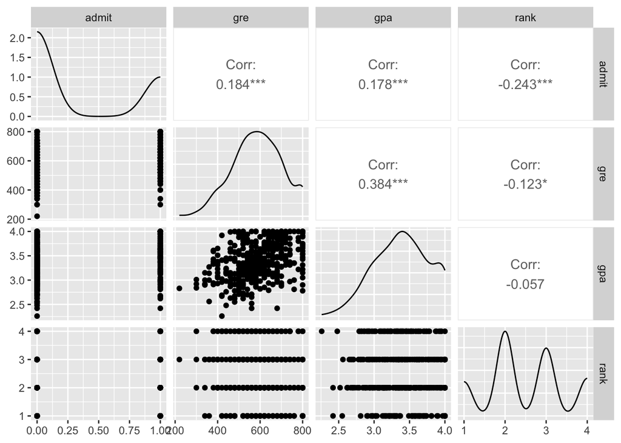

```r
ggpairs(admits)
```

Reviewing the plots, there does not seem to be any single variable with a strong correlation to admit.

## Model Building

Next, models should be developed to see if any combinations of variables are good at predicting the data. First, I’ll look at gre and gpa as an additive model for admit.

```r
mod1 <- glm(data = admits,
            formula = as.logical(admit) ~ gre + gpa,
            family = 'binomial')
performance(mod1)
```

```
## # Indices of model performance
##
## AIC     |    AICc |     BIC | Tjur's R2 |  RMSE | Sigma | Log_loss | Score_log
## ------------------------------------------------------------------------------
## 486.344 | 486.405 | 498.318 |     0.047 | 0.455 | 1.000 |    0.600 |   -48.679
##
## AIC     | Score_spherical |   PCP
## ---------------------------------
## 486.344 |           0.004 | 0.587
```

The model is not great, so let’s try gre and gpa as additive and interactive

```r
mod2 <- glm(data = admits,
            formula = as.logical(admit) ~ gre * gpa,
            family = 'binomial')
performance(mod2)
```

```
## # Indices of model performance
##
## AIC     |    AICc |     BIC | Tjur's R2 |  RMSE | Sigma | Log_loss | Score_log
## ------------------------------------------------------------------------------
## 485.849 | 485.950 | 501.815 |     0.052 | 0.453 | 1.000 |    0.597 |   -48.633
##
## AIC     | Score_spherical |   PCP
## ---------------------------------
## 485.849 |           0.004 | 0.589
```

Now let’s try adding in rank, I’ll just put all of the combinations attempted for these three variables.

```r
mod3 <- glm(data = admits,
            formula = as.logical(admit) ~ gre * gpa * rank,
            family = 'binomial')

mod4 <- aov(data = admits,
             formula = as.logical(admit) ~ gre * gpa * rank)

mod5 <- glm(data = admits,
            formula = as.logical(admit) ~ (gre + gpa) * rank,
            family = 'binomial')

mod6 <- glm(data = admits,
            formula = as.logical(admit) ~ (gre * gpa) + rank,
            family = 'binomial')
compare_performance(mod1, mod2, mod3, mod4, mod5, mod6)
```

```
## # Comparison of Model Performance Indices
##
## Name | Model | AIC (weights) | AICc (weights) | BIC (weights) |  RMSE | Sigma
## -----------------------------------------------------------------------------
## mod1 |   glm | 486.3 (<.001) |  486.4 (<.001) | 498.3 (0.003) | 0.455 | 1.000
## mod2 |   glm | 485.8 (<.001) |  486.0 (<.001) | 501.8 (<.001) | 0.453 | 1.000
## mod3 |   glm | 472.2 (0.051) |  472.6 (0.046) | 504.2 (<.001) | 0.440 | 1.000
## mod4 |   aov | 497.9 (<.001) |  498.3 (<.001) | 533.8 (<.001) | 0.441 | 0.445
## mod5 |   glm | 471.3 (0.082) |  471.5 (0.080) | 495.3 (0.013) | 0.442 | 1.000
## mod6 |   glm | 466.6 (0.867) |  466.7 (0.873) | 486.6 (0.984) | 0.440 | 1.000
##
## Name | Tjur's R2 | Log_loss | Score_log | Score_spherical |   PCP |    R2 | R2 (adj.)
## -------------------------------------------------------------------------------------
## mod1 |     0.047 |    0.600 |   -48.679 |           0.004 | 0.587 |       |
## mod2 |     0.052 |    0.597 |   -48.633 |           0.004 | 0.589 |       |
## mod3 |     0.106 |    0.570 |   -50.593 |           0.005 | 0.613 |       |
## mod4 |           |          |           |                 |       | 0.103 |     0.087
## mod5 |     0.100 |    0.574 |   -50.582 |           0.005 | 0.610 |       |
## mod6 |     0.105 |    0.571 |   -50.481 |           0.004 | 0.612 |       |
```

```r
full_model <- glm(data = admits,
                  formula = as.logical(admit) ~ gre * gpa * rank,
                  family = 'binomial')

stepwise_mod <- stepAIC(full_model, direction = 'both')
```

```
## Start:  AIC=472.25
## as.logical(admit) ~ gre * gpa * rank
##
##                Df Deviance    AIC
## - gre:gpa:rank  1   456.25 470.25
## <none>              456.25 472.25
##
## Step:  AIC=470.25
## as.logical(admit) ~ gre + gpa + rank + gre:gpa + gre:rank + gpa:rank
##
##                Df Deviance    AIC
## - gre:rank      1   456.34 468.34
## - gpa:rank      1   456.58 468.58
## <none>              456.25 470.25
## - gre:gpa       1   459.31 471.31
## + gre:gpa:rank  1   456.25 472.25
##
## Step:  AIC=468.34
## as.logical(admit) ~ gre + gpa + rank + gre:gpa + gpa:rank
##
##            Df Deviance    AIC
## - gpa:rank  1   456.60 466.60
## <none>          456.34 468.34
## - gre:gpa   1   459.33 469.33
## + gre:rank  1   456.25 470.25
##
## Step:  AIC=466.6
## as.logical(admit) ~ gre + gpa + rank + gre:gpa
##
##            Df Deviance    AIC
## <none>          456.60 466.60
## - gre:gpa   1   459.44 467.44
## + gpa:rank  1   456.34 468.34
## + gre:rank  1   456.58 468.58
## - rank      1   477.85 485.85
```

```r
best_model <- glm(data = admits,
                  formula = stepwise_mod$formula,
                  family = 'binomial')
compare_performance(mod1, mod2, mod3, mod4, mod5, mod6, best_model)
```

```
## # Comparison of Model Performance Indices
##
## Name       | Model | AIC (weights) | AICc (weights) | BIC (weights) |  RMSE
## ---------------------------------------------------------------------------
## mod1       |   glm | 486.3 (<.001) |  486.4 (<.001) | 498.3 (0.001) | 0.455
## mod2       |   glm | 485.8 (<.001) |  486.0 (<.001) | 501.8 (<.001) | 0.453
## mod3       |   glm | 472.2 (0.028) |  472.6 (0.025) | 504.2 (<.001) | 0.440
## mod4       |   aov | 497.9 (<.001) |  498.3 (<.001) | 533.8 (<.001) | 0.441
## mod5       |   glm | 471.3 (0.044) |  471.5 (0.043) | 495.3 (0.006) | 0.442
## mod6       |   glm | 466.6 (0.464) |  466.7 (0.466) | 486.6 (0.496) | 0.440
## best_model |   glm | 466.6 (0.464) |  466.7 (0.466) | 486.6 (0.496) | 0.440
##
## Name       | Sigma | Tjur's R2 | Log_loss | Score_log | Score_spherical |   PCP
## -------------------------------------------------------------------------------
## mod1       | 1.000 |     0.047 |    0.600 |   -48.679 |           0.004 | 0.587
## mod2       | 1.000 |     0.052 |    0.597 |   -48.633 |           0.004 | 0.589
## mod3       | 1.000 |     0.106 |    0.570 |   -50.593 |           0.005 | 0.613
## mod4       | 0.445 |           |          |           |                 |
## mod5       | 1.000 |     0.100 |    0.574 |   -50.582 |           0.005 | 0.610
## mod6       | 1.000 |     0.105 |    0.571 |   -50.481 |           0.004 | 0.612
## best_model | 1.000 |     0.105 |    0.571 |   -50.481 |           0.004 | 0.612
##
## Name       |    R2 | R2 (adj.)
## ------------------------------
## mod1       |       |
## mod2       |       |
## mod3       |       |
## mod4       | 0.103 |     0.087
## mod5       |       |
## mod6       |       |
## best_model |       |
```

It does appear that mod6 is best, as it matches with our best model. As a final verification, we can do a radar chart to see which model is best.

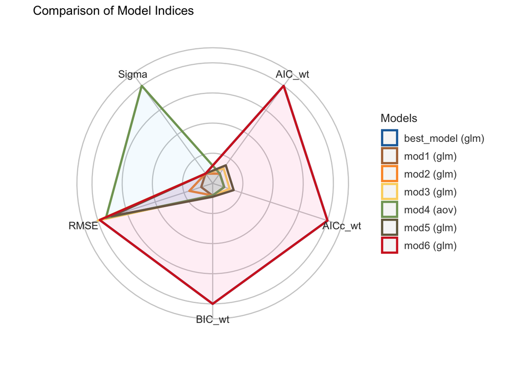

```r
compare_performance(mod1, mod2, mod3, mod4, mod5, mod6, best_model) %>% plot()
```

## Making predictions from the best model

```r
admits$pred1 <- predict(mod6, admits, type = 'response')

admits$pred1 %>% summary()
```

```
##    Min. 1st Qu.  Median    Mean 3rd Qu.    Max.
## 0.01922 0.19732 0.31679 0.31750 0.42447 0.64593
```

Now we can add the following colums to our admits dataset to help verify how well the model predicts the data with the following:

```r
admits <- admits %>%
  mutate(outcome = case_when(pred1 > 0.42 ~ 'Admit',
                             pred1 <= 0.42 ~ 'Denied')) %>%
  mutate(accurate = case_when(admit == 1 & outcome == 'Admit' ~ T,
                              admit == 0 & outcome == 'Denied' ~ T,
                              T ~ F))

overall_accuracy <- admits %>%
  summarise(accuracy = mean(accurate)) %>%
  pull(accuracy)

print(paste0("Overall model accuracy: ", round(overall_accuracy * 100, 2), "%"))
```

```
## [1] "Overall model accuracy: 71%"
```

This shows that the model predicts the data correctly about 71% of the time based on the parameters I set.

## Plotting the model predictions

Lastly, I can plot the model predictions of the data, including hypothetical predictions.

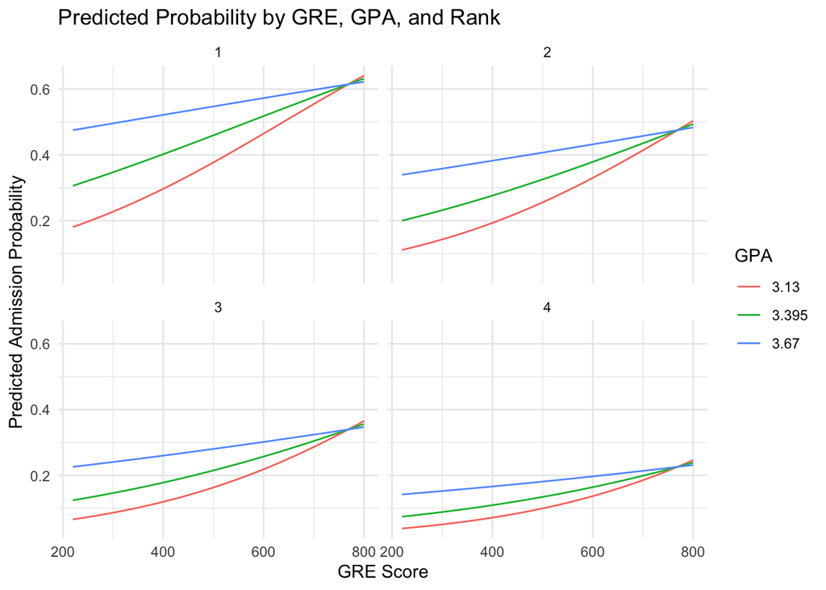

```r
new_data <- expand_grid(
  gre = seq(min(admits$gre), max(admits$gre), length.out = 50),
  gpa = quantile(admits$gpa, probs = c(0.25, 0.5, 0.75)),  # use a few fixed GPA values
  rank = 1:4)

new_data <- new_data %>%
  mutate(pred = predict(mod6, newdata = new_data, type = "response"))

ggplot(new_data, aes(x = gre, y = pred, color = factor(gpa))) +
  geom_line() +
  facet_wrap(~ rank) +
  labs(title = "Predicted Probability by GRE, GPA, and Rank",
       x = "GRE Score", y = "Predicted Admission Probability", color = "GPA") +
  theme_minimal()
```

## Conclusion

Model 6 is the best model and can accurately predict the probability of admission about 71% of the time.